# Movies Dataset

Mehmet Kadri Gofralılar

10/15/2021

## Explaining the Dataset

This data was downloaded by me from https://www.kaggle.com/ruchi798/movies-on-netflix-prime-video-hulu-and-disney.

This dataset is an amalgamation of:

-data that was scraped, which comprised a comprehensive list of **movies** available on various **streaming platforms**

-**IMDb** dataset

At first, we need to read the data.

```r
library(knitr)
movies <- read.csv("data/MoviesOnStreamingPlatforms_updated.csv")
kable(head(movies),format="markdown")
```

| Index | ID | Title | Year | Age | IMDb | Rotten.Tomatoes | Netflix | Hulu | Prime_Video | Disney | Type | Directors | Genres | Country | Language | Runtime |
| --- | --- | --- | --- | --- | --- | --- | --- | --- | --- | --- | --- | --- | --- | --- | --- | --- |
| 0 | 1 | The Irishman | 2019 | 18+ | 7.8/10 | 98/100 | 1 | 0 | 0 | 0 | 0 | Martin Scorsese | Biography,Crime,Drama | United States | English,Italian,Latin,Spanish,German | 209 |
| 1 | 2 | Dangal | 2016 | 7+ | 8.4/10 | 97/100 | 1 | 0 | 0 | 0 | 0 | Nitesh Tiwari | Action,Biography,Drama,Sport | India,United States,United Kingdom,Australia,Kenya,Namibia | Hindi,English | 161 |
| 2 | 3 | David Attenborough: A Life on Our Planet | 2020 | 7+ | 9.0/10 | 95/100 | 1 | 0 | 0 | 0 | 0 | Alastair Fothergill,Jonathan Hughes,Keith Scholey | Documentary,Biography | United Kingdom | English | 83 |
| 3 | 4 | Lagaan: Once Upon a Time in India | 2001 | 7+ | 8.1/10 | 94/100 | 1 | 0 | 0 | 0 | 0 | Ashutosh Gowariker | Drama,Musical,Sport | India,United Kingdom | Hindi,English | 224 |
| 4 | 5 | Roma | 2018 | 18+ | 7.7/10 | 94/100 | 1 | 0 | 0 | 0 | 0 |  | Action,Drama,History,Romance,War | United Kingdom,United States | English | 52 |
| 5 | 6 | To All the Boys I’ve Loved Before | 2018 | 13+ | 7.1/10 | 94/100 | 1 | 0 | 0 | 0 | 0 | Susan Johnson | Comedy,Drama,Romance | United States | English | 99 |

## Cleaning the Data

Now, we have to tidy the data a little bit.

```r
movies$Platform="NotDetermined"
rowCount <- nrow(movies)
for (platformColumn in 8:11) {
     for (i in 1:rowCount) {
         if (movies[i,platformColumn]==1) {
             movies[i,18]=colnames(movies[platformColumn])
         }
     }
 }

movies <- subset( movies, select = -Netflix )
movies <- subset( movies, select = -Hulu )
movies <- subset( movies, select = -Prime_Video )
movies <- subset( movies, select = -Disney )
movies <- subset( movies, select = -Index )
movies <- subset( movies, select = -Type )

movie_df <-as_tibble(select(movies, Title, Year, Age, IMDb, Rotten.Tomatoes, Platform, Genres, Country, Language, Runtime))

movie_df <- filter(movie_df, (IMDb!=''))

movie_df <- movie_df %>%
separate(IMDb, into = c("IMDb", "imdb_will_be_deleted"), sep = "/" , convert = TRUE)

movie_df <- filter(movie_df, (Rotten.Tomatoes!=''))

movie_df <- movie_df %>%
separate(Rotten.Tomatoes, into = c("Rotten.Tomatoes", "Rotten.Tomatoes_will_be_deleted") , sep = "/" , convert = TRUE)
movie_df <- subset( movie_df, select = - imdb_will_be_deleted )
movie_df <- subset( movie_df, select = - Rotten.Tomatoes_will_be_deleted )

movie_df$Platform <- as.factor(movie_df$Platform)

head(movie_df)
```

```
## # A tibble: 6 x 10
##   Title    Year Age    IMDb Rotten.Tomatoes Platform Genres  Country   Language
##   <chr>   <int> <chr> <dbl>           <int> <fct>    <chr>   <chr>     <chr>
## 1 The Ir~  2019 18+     7.8              98 Netflix  Biogra~ United S~ English,~
## 2 Dangal   2016 7+      8.4              97 Netflix  Action~ India,Un~ Hindi,En~
## 3 David ~  2020 7+      9                95 Netflix  Docume~ United K~ English
## 4 Lagaan~  2001 7+      8.1              94 Netflix  Drama,~ India,Un~ Hindi,En~
## 5 Roma     2018 18+     7.7              94 Netflix  Action~ United K~ English
## 6 To All~  2018 13+     7.1              94 Netflix  Comedy~ United S~ English
## # ... with 1 more variable: Runtime <int>
```

We’ve converted our dataframe to tibble, because tibbles have a refined print method that shows only the first 10 rows, and all the columns that fit on screen.

Now, lets see age restriction of movies:

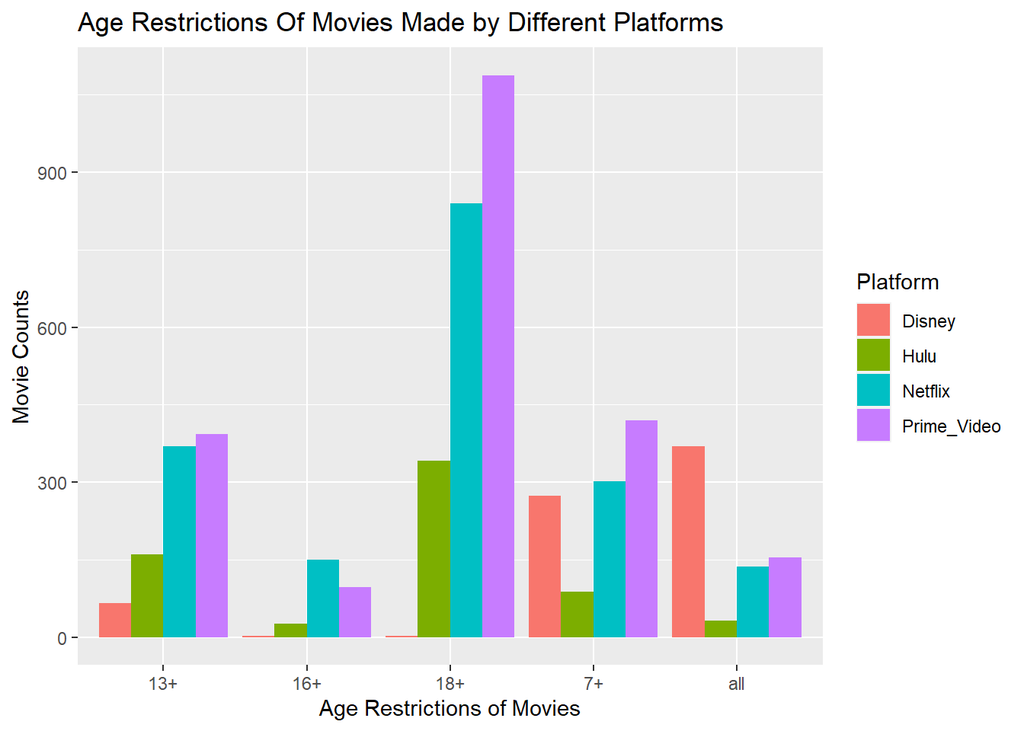

```r
ggplot(filter(movie_df, Age!="")) +
     geom_bar(mapping=aes(x = Age, fill= Platform),position = "dodge")+
     labs(
         x = "Age Restrictions of Movies",
         y = "Movie Counts",
         title = "Age Restrictions Of Movies Made by Different Platforms")
```

By looking at this graph, we can say that Prime Video and Netflix have been providing 18+ movies much more than Disney and Hulu. Also Disney has been providing movies for audience of all ages mostly. Therefore, if a company were to decide on making a deal with a streaming service provider, they could decide based on the movie’s targeted age.

Also if we look into the ratings of movies on IMDb and RottenTomatoes provided, we can see if the streaming service providers matter or not for the popularity of the movie.

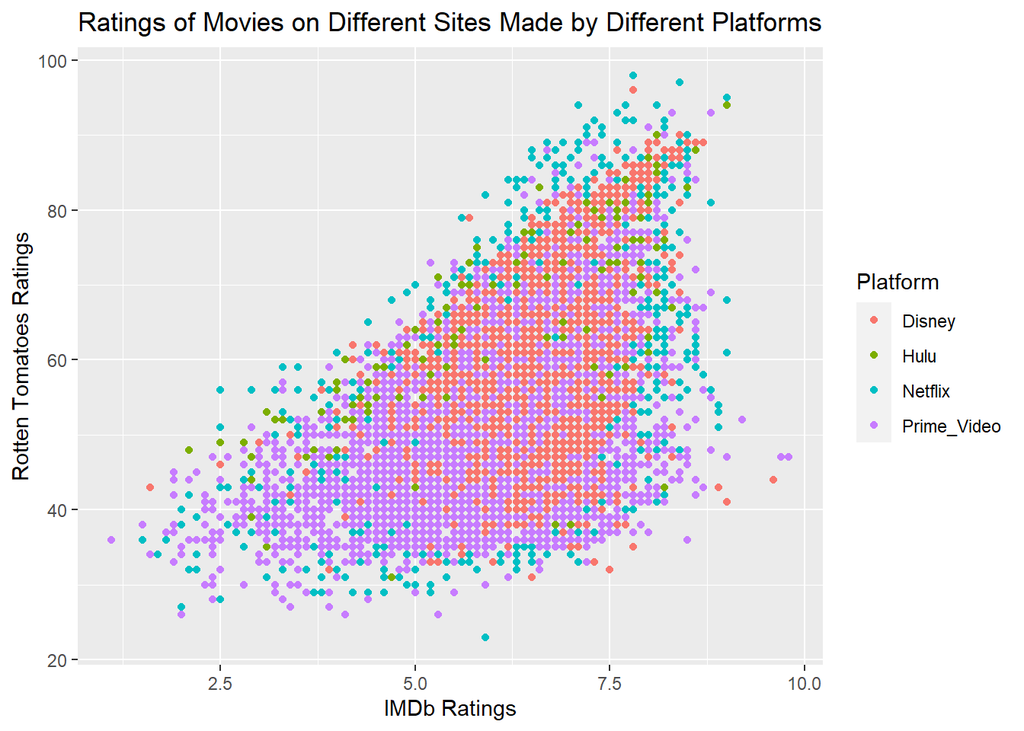

```r
ggplot(movie_df) +
    geom_point(mapping=aes(x = IMDb, y = Rotten.Tomatoes, color= Platform))+
     labs(
         x = "IMDb Ratings",
         y = "Rotten Tomatoes Ratings",
         title = "Ratings of Movies on Different Sites Made by Different Platforms")
```

Since the graph is too crowded, lets zoom in on the year 2021:

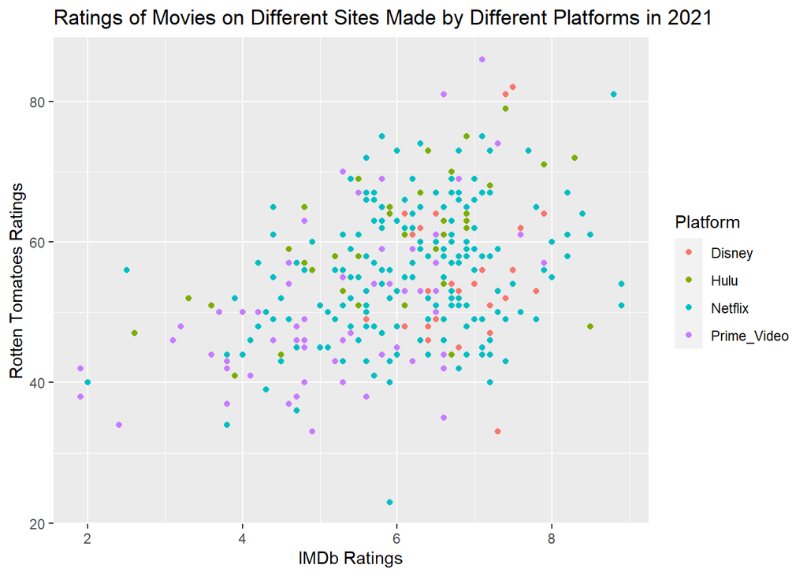

```r
ggplot(filter(movie_df, Year==2021)) +
    geom_point(mapping=aes(x = IMDb, y = Rotten.Tomatoes, color= Platform)) +
     labs(
         x = "IMDb Ratings",
         y = "Rotten Tomatoes Ratings",
         title = "Ratings of Movies on Different Sites Made by Different Platforms in 2021")
```

When we look at the year 2021, Netflix movies has been rated higher than most of the other platforms and Prime Videos movies are usually at the bottom of the rating. Also Disney movies are rated neutral and higher.